# Austin - 311 Calls

## Background

City of Austin 3-1-1 service for Police non-emergency calls. This helped to reduce the number of calls to 9-1-1 so they could concentrate on those calls where either life and /or property were in danger.

- Link: http://www.austintexas.gov/department/about-3-1-1

## BigQuery

Google BigQuery provides access to the 3-1-1 data as part of their Public Data project:  
`bigquery-public-data:austin_311.311_service_requests`

```r
library(DBI)
library(bigrquery)

con <- dbConnect(
  bigquery(),
  project = "bigquery-public-data",
  dataset = "austin_311",
  billing = "rstudio-bigquery-event",
  use_legacy_sql = FALSE
)
```

## dplyr with BigQuery

Instead of importing the entire data set, we just create a pointer to the table inside BigQuery:

```r
service <- tbl(con, "311_service_requests")
```

Standard `dplyr` commands work inside BigQuery:

```r
glimpse(service)
```

```
Observations: ??
Variables: 24
Database: BigQueryConnection
$ unique_key               <chr> "16-", "14-00097246", "16-00125960", "16...
$ complaint_type           <chr> NA, "ACDEADBI", "ACLONAG", "ACLONAG", "A...
$ complaint_description    <chr> NA, "Dead Bird", "Loose Dog", "Loose Dog...
$ owning_department        <chr> NA, "Animal Services Office", "Animal Se...
$ source                   <chr> NA, "Phone", "Spot311 Interface", "Spot3...
$ status                   <chr> NA, "Closed", "Closed", "Closed", "Close...
$ status_change_date       <dttm> NA, 2014-05-21 14:18:20, 2016-05-25 13:...
$ created_date             <dttm> NA, 2014-05-21 12:13:57, 2016-05-24 21:...
$ last_update_date         <dttm> NA, 2014-05-21 13:20:26, 2016-05-25 12:...
$ close_date               <dttm> NA, 2014-05-21 14:18:20, 2016-05-25 13:...
$ incident_address         <chr> NA, "BARTON SPRINGS RD &S 1ST ST, AUSTIN...
$ street_number            <chr> NA, NA, "1215", "2207", "607", "902", "9...
$ street_name              <chr> NA, "BARTON SPRINGS RD &S 1ST ST", "DELA...
$ city                     <chr> NA, "AUSTIN", "AUSTIN", "AUSTIN", "AUSTI...
$ incident_zip             <int> NA, 78704, NA, NA, NA, NA, NA, NA, NA, N...
$ county                   <chr> NA, "TRAVIS", NA, NA, NA, NA, NA, NA, NA...
$ state_plane_x_coordinate <chr> NA, "3112101.75", "3134663.24798805", "3...
$ state_plane_y_coordinate <dbl> NA, 10067179, 10073569, 10037011, 100464...
$ latitude                 <dbl> NA, 30.258382, 30.274486, 30.176942, 30....
$ longitude                <dbl> NA, -97.75007, -97.67815, -97.82712, -97...
$ location                 <chr> NA, "(30.25838165, -97.75007215)", "(30....
$ council_district_code    <int> NA, 9, NA, NA, NA, NA, NA, NA, NA, NA, N...
$ map_page                 <chr> NA, "615A", NA, NA, NA, NA, NA, NA, NA, ...
$ map_tile                 <chr> NA, "MJ21", NA, NA, "MG16", "MG16", "MG1...
```

```r
tally(service)
```

```
Complete
Billed: 0 B
Downloading 1 rows in 1 pages.
```

| n |
| --- |
| 661260 |

Which are the most common complaints?

```r
service %>%
  count(complaint_description) %>%
  top_n(10)
```

```
Complete
Billed: 18.87 MB
Downloading 10 rows in 1 pages.
```

| complaint_description | n |
| --- | --- |
| Austin Code - Request Code Officer | 117639 |
| Traffic Signal - Maintenance | 43082 |
| Loose Dog | 42981 |
| ARR Missed Recycling | 30615 |
| Animal Control - Assistance Request | 29023 |
| ARR Dead Animal Collection | 28895 |
| Street Light Issue- Address | 27102 |
| Injured / Sick Animal | 20418 |
| Water Waste Report | 15289 |
| Pothole Repair | 14510 |

Some data cleaning…

```r
service <- service %>%
  filter(latitude > 10)
```

## Visualizations using dbplot, ggplot2 and leaflet

Easily view the location of the service calls without importing all of the data.

```
Complete
Billed: 29.36 MB
Downloading 1,047 rows in 1 pages.
```

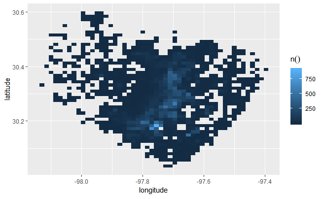

```r
library(dbplot)

complaint <- "Loose Dog"

service %>%
  filter(complaint_description == complaint) %>%
  dbplot_raster(longitude, latitude, resolution = 50)
```

```r
NA
```

Use the new `db_computer_raster2()` function to obtain the pre-calculated squares, with their limits included.

```r
calls <- service %>%
  filter(complaint_description == complaint) %>%
  db_compute_raster2(longitude, latitude, resolution = 30) %>%
  mutate(of_max = `n()` / max(`n()`))
```

```
Complete
Billed: 29.36 MB
Downloading 486 rows in 1 pages.
```

```r
calls
```

| longitude | latitude | n() | longitude_2 | latitude_2 | of_max |
| --- | --- | --- | --- | --- | --- |
| -97.80650 | 30.37925 | 13 | -97.78152 | 30.39831 | 0.0074498567 |
| -97.75655 | 30.18866 | 1745 | -97.73157 | 30.20772 | 1.0000000000 |
| -98.00631 | 30.36019 | 1 | -97.98133 | 30.37925 | 0.0005730659 |
| -97.58172 | 30.32208 | 45 | -97.55674 | 30.34113 | 0.0257879656 |
| -97.45683 | 30.32208 | 7 | -97.43186 | 30.34113 | 0.0040114613 |
| -97.60669 | 30.16960 | 20 | -97.58172 | 30.18866 | 0.0114613181 |
| -98.05626 | 30.37925 | 2 | -98.03128 | 30.39831 | 0.0011461318 |
| -97.73157 | 30.20772 | 172 | -97.70660 | 30.22678 | 0.0985673352 |
| -97.53176 | 30.36019 | 42 | -97.50679 | 30.37925 | 0.0240687679 |
| -97.88143 | 30.49361 | 1 | -97.85645 | 30.51267 | 0.0005730659 |

[output cut: 476 more lines]

Overlay the squares over a map of Austin using `leaflet`

```r
library(leaflet)

leaflet() %>%
  addTiles() %>%
  addRectangles(
    calls$longitude,
    calls$latitude,
    calls$longitude_2,
    calls$latitude_2
  )
```

[interactive chart not shown]

Make it fancy… Highlight squares based on number of comparative number of calls, and add a popup

```r
fancy <- leaflet() %>%
  addTiles() %>%
  addRectangles(
    calls$longitude,
    calls$latitude,
    calls$longitude_2,
    calls$latitude_2,
    fillOpacity = calls$of_max,
    fillColor = "red",
    stroke = FALSE,
    popup = paste0("<p>Calls: ",  calls$`n()`,"</p>")
  )

fancy
```

[interactive chart not shown]

Where’s the Fairmont?

```r
fancy  %>%
  addMarkers(lng = -97.7404001, lat = 30.2620562)
```

[interactive chart not shown]

## Kmeans with modeldb

Calculate k-means inside the database using `simple_kmeans_db()`

```r
service_kmeans <-  service %>%
  filter(complaint_description == complaint) %>%
  simple_kmeans_db(latitude, longitude)
```

[output not shown]

[output cut: 22 more lines]

[output not shown]

```r
head(service_kmeans, 10)
```

```
Running job 'rstudio-bigquery-event.job_ZKRgCGLmiALdMukxLXJUwxFpPjdR.US' ...
Complete
Billed: 190.84 MB
Downloading 10 rows in 1 pages.
```

| k_center | k_latitude | k_longitude | unique_key | complaint_type | complaint_description | owning_department | source | status | status_change_date | created_date | last_update_date | close_date | incident_address | street_number | street_name | city | incident_zip | county | state_plane_x_coordinate | state_plane_y_coordinate | latitude | longitude | location | council_district_code | map_page | map_tile |
| --- | --- | --- | --- | --- | --- | --- | --- | --- | --- | --- | --- | --- | --- | --- | --- | --- | --- | --- | --- | --- | --- | --- | --- | --- | --- | --- |
| center_1 | 30.34095 | -97.66852 | 16-00125960 | ACLONAG | Loose Dog | Animal Services Office | Spot311 Interface | Closed | 2016-05-25 13:07:15 | 2016-05-24 21:41:22 | 2016-05-25 12:07:31 | 2016-05-25 13:07:15 | 1215 DELANO ST, AUSTIN, TX 78721 | 1215 | DELANO | AUSTIN | NA | NA | 3134663.24798805 | 10073569 | 30.27449 | -97.67815 | (30.27448616, -97.6781494) | NA | NA | NA |
| center_2 | 30.20663 | -97.74930 | 16-00287195 | ACLONAG | Loose Dog | Animal Services Office | Spot311 Interface | Closed | 2016-10-29 16:59:00 | 2016-10-29 12:01:21 | 2016-10-29 15:59:19 | 2016-10-29 16:59:00 | 2207 LEAH CV, AUSTIN, TX 78748 | 2207 | LEAH | AUSTIN | NA | NA | 3088450.75244673 | 10037011 | 30.17694 | -97.82712 | (30.17694153, -97.8271166) | NA | NA | NA |
| center_2 | 30.20663 | -97.74930 | 16-00287017 | ACLONAG | Loose Dog | Animal Services Office | Spot311 Interface | Closed | 2016-10-29 16:22:51 | 2016-10-29 06:30:14 | 2016-10-29 15:23:09 | 2016-10-29 16:22:51 | 607 BLUEBERRY HILL, AUSTIN, TX 78745 | 607 | BLUEBERRY HILL | AUSTIN | NA | NA | 3101726.75 | 10046477 | 30.20213 | -97.78443 | (30.20213293, -97.78442704) | NA | NA | MG16 |
| center_2 | 30.20663 | -97.74930 | 16-00287018 | ACLONAG | Loose Dog | Animal Services Office | Spot311 Interface | Closed | 2016-10-29 16:13:49 | 2016-10-29 06:30:20 | 2016-10-29 15:14:07 | 2016-10-29 16:13:49 | 902 SIROCCO DR, AUSTIN, TX 78745 | 902 | SIROCCO | AUSTIN | NA | NA | 3100020.50224563 | 10046864 | 30.20330 | -97.78980 | (30.20330411, -97.78979875) | NA | NA | MG16 |
| center_2 | 30.20663 | -97.74930 | 16-00287019 | ACLONAG | Loose Dog | Animal Services Office | Spot311 Interface | Duplicate (closed) | 2016-10-29 06:30:22 | 2016-10-29 06:30:22 | 2016-10-29 15:14:08 | 2016-10-29 06:30:22 | 904 SIROCCO DR, AUSTIN, TX 78745 | 904 | SIROCCO | AUSTIN | NA | NA | 3099980.50105781 | 10046904 | 30.20342 | -97.78992 | (30.20341658, -97.78992245) | NA | NA | MG17 |
| center_1 | 30.34095 | -97.66852 | 16-00287114 | ACLONAG | Loose Dog | Animal Services Office | Spot311 Interface | Closed | 2016-10-29 14:19:19 | 2016-10-29 10:28:07 | 2016-10-29 13:19:37 | 2016-10-29 14:19:19 | 14720 LIPTON LN, PFLUGERVILLE, TX 78660 | 14720 | LIPTON | PFLUGERVILLE | NA | NA | 3147891.81833236 | 10127045 | 30.42061 | -97.63214 | (30.42060509, -97.63214218) | NA | NA | NA |
| center_1 | 30.34095 | -97.66852 | 16-00287156 | ACLONAG | Loose Dog | Animal Services Office | Phone | Closed | 2016-10-29 17:14:04 | 2016-10-29 11:26:26 | 2016-10-29 16:14:23 | 2016-10-29 17:14:04 | 1520 RUTHERFORD LN, AUSTIN, TX 78754 | 1520 | RUTHERFORD | AUSTIN | NA | NA | 3133220.45999999 | 10096591 | 30.33786 | -97.68098 | (30.33786336, -97.68097994) | NA | NA | NA |
| center_1 | 30.34095 | -97.66852 | 18-00388384 | ACLONAG | Loose Dog | Animal Services Office | Phone | Closed | 2019-01-10 11:34:22 | 2018-11-12 09:57:49 | 2019-01-10 11:34:22 | 2019-01-10 11:34:22 | PAMELA DR & SCARLET ST, AUSTIN, TX | NA | PAMELA DR & SCARLET ST | AUSTIN | NA | NA | 3135555.99765578 | 10138186 | 30.45205 | -97.67042 | (30.45204785, -97.67042245) | NA | NA | NA |
| center_1 | 30.34095 | -97.66852 | 15-00025334 | ACLONAG | Loose Dog | Animal Services Office | Phone | Closed | 2018-12-07 09:55:00 | 2015-02-06 10:34:00 | 2018-12-07 09:55:00 | 2018-12-07 09:55:00 | 9345 E US 290 HWY EB, AUSTIN, TX | 9345 | 290 | AUSTIN | NA | NA | 3145457.159 | 10093864 | 30.32956 | -97.64241 | (30.32956006, -97.64241058) | NA | NA | NA |
| center_3 | 30.42270 | -97.85656 | 17-00135640 | ACLONAG | Loose Dog | Animal Services Office | Phone | Closed | 2017-05-23 11:25:39 | 2017-05-22 17:23:58 | 2017-05-23 11:25:39 | 2017-05-23 11:25:39 | ROCK CLIFF DR & FAWN DR, LEANDER, TX 78641 | NA | ROCK CLIFF DR & FAWN DR | leander | 78641 | TRAVIS | 3035748.94045823 | 10189890 | 30.60036 | -97.98365 | (30.60036004, -97.9836451) | NA | 309K | WW50 |

Preview the final SQL statement that the routine settled on

```r
show_query(service_kmeans)
```

```
<SQL>
SELECT `RHS`.`center` AS `k_center`, `LHS`.`k_latitude` AS `k_latitude`, `LHS`.`k_longitude` AS `k_longitude`, `RHS`.`unique_key` AS `unique_key`, `RHS`.`complaint_type` AS `complaint_type`, `RHS`.`complaint_description` AS `complaint_description`, `RHS`.`owning_department` AS `owning_department`, `…
FROM (SELECT `center` AS `k_center`, `latitude` AS `k_latitude`, `longitude` AS `k_longitude`
FROM (SELECT `center`, AVG(`latitude`) AS `latitude`, AVG(`longitude`) AS `longitude`
FROM (SELECT `latitude`, `longitude`, `center`
FROM (SELECT *
FROM (SELECT `unique_key`, `complaint_type`, `complaint_description`, `owning_department`, `source`, `status`, `status_change_date`, `created_date`, `last_update_date`, `close_date`, `incident_address`, `street_number`, `street_name`, `city`, `incident_zip`, `county`, `state_plane_x_coordinate`, `st…
WHEN (`center_1` >= `center_1` AND `center_1` < `center_2` AND `center_1` < `center_3`) THEN ('center_1')
WHEN (`center_2` < `center_1` AND `center_2` >= `center_2` AND `center_2` < `center_3`) THEN ('center_2')
WHEN (`center_3` < `center_1` AND `center_3` < `center_2` AND `center_3` >= `center_3`) THEN ('center_3')
END AS `center`
FROM (SELECT `unique_key`, `complaint_type`, `complaint_description`, `owning_department`, `source`, `status`, `status_change_date`, `created_date`, `last_update_date`, `close_date`, `incident_address`, `street_number`, `street_name`, `city`, `incident_zip`, `county`, `state_plane_x_coordinate`, `st…
FROM (SELECT *
FROM (SELECT *
FROM `311_service_requests`
WHERE (`latitude` > 10.0)) `dbplyr_dhbllplike`
WHERE (`complaint_description` = 'Loose Dog')) `dbplyr_dnaufqnrzl`) `dbplyr_kgluvrnawn`) `dbplyr_lptlwvibbx`
WHERE (NOT(((`center`) IS NULL)))) `dbplyr_bcwrtzcguo`) `dbplyr_nzubfbwxvc`
GROUP BY `center`) `dbplyr_klkfotpktf`) `LHS`
RIGHT JOIN (SELECT `unique_key`, `complaint_type`, `complaint_description`, `owning_department`, `source`, `status`, `status_change_date`, `created_date`, `last_update_date`, `close_date`, `incident_address`, `street_number`, `street_name`, `city`, `incident_zip`, `county`, `state_plane_x_coordinate…
FROM (SELECT `unique_key`, `complaint_type`, `complaint_description`, `owning_department`, `source`, `status`, `status_change_date`, `created_date`, `last_update_date`, `close_date`, `incident_address`, `street_number`, `street_name`, `city`, `incident_zip`, `county`, `state_plane_x_coordinate`, `st…
WHEN (`center_1` >= `center_1` AND `center_1` < `center_2` AND `center_1` < `center_3`) THEN ('center_1')
WHEN (`center_2` < `center_1` AND `center_2` >= `center_2` AND `center_2` < `center_3`) THEN ('center_2')
WHEN (`center_3` < `center_1` AND `center_3` < `center_2` AND `center_3` >= `center_3`) THEN ('center_3')
END AS `center`
FROM (SELECT `unique_key`, `complaint_type`, `complaint_description`, `owning_department`, `source`, `status`, `status_change_date`, `created_date`, `last_update_date`, `close_date`, `incident_address`, `street_number`, `street_name`, `city`, `incident_zip`, `county`, `state_plane_x_coordinate`, `st…
FROM (SELECT *
FROM (SELECT *
FROM `311_service_requests`
WHERE (`latitude` > 10.0)) `dbplyr_wbqfjmxhal`
WHERE (`complaint_description` = 'Loose Dog')) `dbplyr_ggjyiqfzcp`) `dbplyr_okmwddcmul`) `dbplyr_eyichlgmri`
WHERE (NOT(((`center`) IS NULL)))) `RHS`
ON (`LHS`.`k_center` = `RHS`.`center`)
```

Create a local table with the corners of each center

```r
cr <- service_kmeans %>%
  group_by(k_longitude, k_latitude) %>%
  summarise(
    calls = n(),
    lat1 = min(latitude, na.rm = TRUE),
    lat2 = max(latitude, na.rm = TRUE),
    lon1 = min(longitude, na.rm = TRUE),
    lon2 = max(longitude, na.rm = TRUE),
  ) %>%
  collect()
```

```
Running job 'rstudio-bigquery-event.job_cMXfozzih5bq--ODWvcndFdtDw3Y.US' ...
Complete
Billed: 29.36 MB
Downloading 3 rows in 1 pages.
```

```r
cr
```

| k_longitude | k_latitude | calls | lat1 | lat2 | lon1 | lon2 |
| --- | --- | --- | --- | --- | --- | --- |
| -97.85656 | 30.42270 | 2689 | 30.23505 | 30.60796 | -98.13119 | -97.73944 |
| -97.66852 | 30.34095 | 19138 | 30.17572 | 30.53560 | -97.77910 | -97.38191 |
| -97.74930 | 30.20663 | 21146 | 30.03619 | 30.32024 | -97.98325 | -97.55269 |

Plot against a map

```r
leaflet() %>%
  addTiles() %>%
  addRectangles(cr$lon1, cr$lat1, cr$lon2, cr$lat2)
```

[interactive chart not shown]

Overlay the raster boxes

```r
leaflet() %>%
  addTiles() %>%
  addRectangles(cr$lon1, cr$lat1, cr$lon2, cr$lat2) %>%
  addRectangles(
    calls$longitude,
    calls$latitude,
    calls$longitude_2,
    calls$latitude_2,
    fillColor = "red",
    stroke = FALSE,
    popup = paste0("<p>Calls: ",  calls$`n()`,"</p>")
  )
```

[interactive chart not shown]

```r
NA
```

## Bringing it all together

Use `purrr` to run `db_compute_raster()` for each center in the kmeans results

```r
library(purrr)

cents <- c("center_1", "center_2", "center_3")

by_centers <- cents %>%
  map_df(~{
    bc <- service_kmeans %>%
      filter(k_center == .x) %>%
      db_compute_raster2(longitude, latitude, resolution =  20) %>%
      mutate(
        of_max = `n()` / max(`n()`),
        center = .x
        )
    })
```

```
Running job 'rstudio-bigquery-event.job_t9e7XLa-4RfFvoj6Gi_9hVMIHSpw.US' ...
Complete
Billed: 29.36 MB
Downloading 226 rows in 1 pages.

Running job 'rstudio-bigquery-event.job_brc4wink6YvAREplgDp0PaR2jMf8.US' ...
Complete
Billed: 29.36 MB
Downloading 221 rows in 1 pages.

Running job 'rstudio-bigquery-event.job_9QpyUEDDDc8TCmFAdXpb3PUBXey_.US' ...
Complete
Billed: 29.36 MB
Downloading 209 rows in 1 pages.
```

Change the color of each center

```r
bc <- by_centers %>%
  mutate(color = case_when(
    center == "center_1" ~ "red",
    center == "center_2" ~ "blue",
    center == "center_3" ~ "green",
    TRUE ~ "white"
  ))

bc
```

| longitude | latitude | n() | longitude_2 | latitude_2 | of_max | center | color |
| --- | --- | --- | --- | --- | --- | --- | --- |
| -97.52092 | 30.33767 | 22 | -97.50106 | 30.35566 | 0.0209324453 | center_1 | red |
| -97.62022 | 30.48162 | 11 | -97.60036 | 30.49961 | 0.0104662226 | center_1 | red |
| -97.56064 | 30.39165 | 2 | -97.54078 | 30.40964 | 0.0019029496 | center_1 | red |
| -97.46134 | 30.28368 | 7 | -97.44149 | 30.30168 | 0.0066603235 | center_1 | red |
| -97.75924 | 30.40964 | 44 | -97.73938 | 30.42764 | 0.0418648906 | center_1 | red |
| -97.69966 | 30.49961 | 2 | -97.67980 | 30.51761 | 0.0019029496 | center_1 | red |
| -97.71952 | 30.42764 | 52 | -97.69966 | 30.44563 | 0.0494766889 | center_1 | red |
| -97.62022 | 30.35566 | 123 | -97.60036 | 30.37366 | 0.1170313987 | center_1 | red |
| -97.75924 | 30.31967 | 92 | -97.73938 | 30.33767 | 0.0875356803 | center_1 | red |
| -97.58050 | 30.40964 | 4 | -97.56064 | 30.42764 | 0.0038058991 | center_1 | red |

[output cut: 646 more lines]

Map the two layers together

```r
leaflet() %>%
  addTiles()  %>%
  addRectangles(cr$lon1, cr$lat1, cr$lon2, cr$lat2) %>%
  addRectangles(
    bc$longitude,
    bc$latitude,
    bc$longitude_2,
    bc$latitude_2,
    fillColor = bc$color,
    fillOpacity = 0.5,
    stroke = FALSE,
    popup = paste0("<p>Calls: ",  bc$`n()`,"</p>")
  )
```

[interactive chart not shown]

```r
dbDisconnect(con)
```